# Praca domowa 1

Rafał Grądziel

6 marca 2016

# Wprowadzenie

W zeszłym tygodniu zostały przyznane nagrody Amerykańskiej Akademii Sztuki i Wiedzy Filmowej znane wszystkim jako **Oscar’y**. W oparciu o zbiór 50 tys. tweet’ów przed rozdaniem oraz 50 tys. po rozdaniu nagród - zawierających w sobie słowo “Oscar” - przeprowadziłem poniżej analizę kilku wybranych parametrów.

Oto przykładowe wywołanie kilku elementów pobranej bazy:

```r
tweetsprzed <- read.csv(file="C:\\Users\\Rafał\\Desktop\\do\\RiBigData\\twitterList2.csv")
tweets <- read.csv(file="C:\\Users\\Rafał\\Desktop\\do\\RiBigData\\tweetList.csv")
head(tweets)
```

```
##   X
## 1 1
## 2 2
## 3 3
## 4 4
## 5 5
## 6 6
##                                                                                                                                           text
## 1 RT @theJeremyVine: Leonardo di Caprio to the woman who puts nameplate on Oscar statuette: "You do this every year ... I wouldn't know" http…
## 2                                       RT @Dory: QUICK SPREAD THESE LEONARDO DICAPRIO OSCAR JOKES WHILE YOU STILL CAN https://t.co/qeKBTbFx9O
## 3                                                      RT @MissSexty: No entiendo como a mí no me dan un Oscar con las películas que me monto.
## 4                                         RT @whoabiebz: THIS IS LEONARDO DICAPRIO HOLDING HIS OSCAR. RT FOR GOOD LUCK https://t.co/yoiBYTM0BF
## 5                                     Gostei de um vídeo @YouTube de @luccasnetobr https://t.co/4osSEYCwun IMITANDO GLORIA PIRES NO OSCAR 2016
## 6 RT @Variety_Claudia: Emmanuel 'Chivo' Lubezki, who just won an Oscar for "The Revenent," is the first DP to ever be on our Variety cover! h…
##   favorited favoriteCount replyToSN             created truncated
```

[output cut: 27 more lines]

## 1. Nagrodzeni

Wiemy już kto został nagrodzony, jednakże kto najczęściej pojawiał się w tweet’ach **po** gali- czyja wygrana była najszerzej komentowana?

Za pomoca pakietu *stringi* zliczymy, ile razy pojawiały się nazwiska zwyciezców w pobranej bazie. Dodatkowo, aby uniknąć problemu związanego z case sensitive, cały tekst bedzie zapisany dużymi literami.

```r
library(stringi)
tekst=toupper(tweets$text)
dicaprio=sum(stri_count(tekst,fixed="DICAPRIO"))
spotlight=sum(stri_count(tekst,fixed="SPOTLIGHT"))
larson=sum(stri_count(tekst,fixed="LARSON"))
rylance=sum(stri_count(tekst,fixed="RYLANCE"))
vikander=sum(stri_count(tekst,fixed="VIKANDER"))
alejandro=sum(stri_count(tekst,fixed="ALEJANDRO"))
ssmith=sum(stri_count(tekst,fixed="SAM SMITH"))
synszawla=sum(stri_count(tekst,fixed="SAUL FIA"))
bigshort=sum(stri_count(tekst,fixed="BIG SHORT"))
```

| Nagroda | Kto | Wartość |
| --- | --- | --- |
| Aktor pierwszoplanowy | Leonardo DiCaprio | 9449 |
| Aktorka pierwszoplanowa | Brie Larson | 335 |
| Film | Spotlight | 744 |
| Reżyser | Alejandro Inarritu | 132 |
| Piosenka | Writing’s on the Wall | 394 |
| Aktor drugoplanowy | Mark Rylance | 54 |
| Aktorka drugoplanowa | Alicia Vikander | 158 |
| Film nieanglojęzyczny | Saul Fia / Syn Szawła | 1 |
| Scenariusz adaptowany | Big Short | 15 |

| Film | Wartość |
| --- | --- |
| Zjawa | 445 |
| Spotlight | 744 |

## 2. Nagroda wieczoru - przed i po..

Znacząca część osób, która interesuje się galą rozdania Oscar’ów, zwróciła w tym roku swoją uwagę na przede wszystkim jedną kategorię - czy Leonardo DiCaprio otrzyma nagrodę dla aktora pierwszoplanowego? Korzystając z dwóch zbiorów CSV - tweet’y przed i po gali rozważmy jak często wspominane były nazwiska nominowanych do tej nagrody.

| Kto | Przed | Po |
| --- | --- | --- |
| Leonardo DiCaprio | 9334 | 9449 |
| Matt Damon | 53 | 30 |
| Eddie Redmayne | 706 | 80 |
| Michael Fassbender | 58 | 69 |
| Bryan Cranston | 58 | 7 |

Wprost z tabeli wnioskujemy, że najwiecej osób pisało tweet’y dotyczące DiCaprio, zarówno przed i po rozdaniu nagród. Jednakże, zauważalny jest dość znaczący spadek w postach dotyczących Eddie’go Redmayne. Wydaje się być to spowodwoane tym, że przed galą wiele osób uważało, że to właśnie jemu należy się Oscar za niesamowitą rolę w filmie “Dziewczyna z portretu” - zagrał kobietę w tym filmie.

## 3. Technologia to ważna rzecz

Obecnie tweet’ować można z większości urządzeń elektornicznych za pomocą aplikacji lub tradycyjnie z przeglądarki. Rozważając dane przed i po rozdaniu nagród, jako jeden zbiór, spójrzmy jak często tweet’ujemy z:

- Iphone’a
- Androida
- Standardowo przez przeglądarke - *Web Client* lub *Tweet Deck*

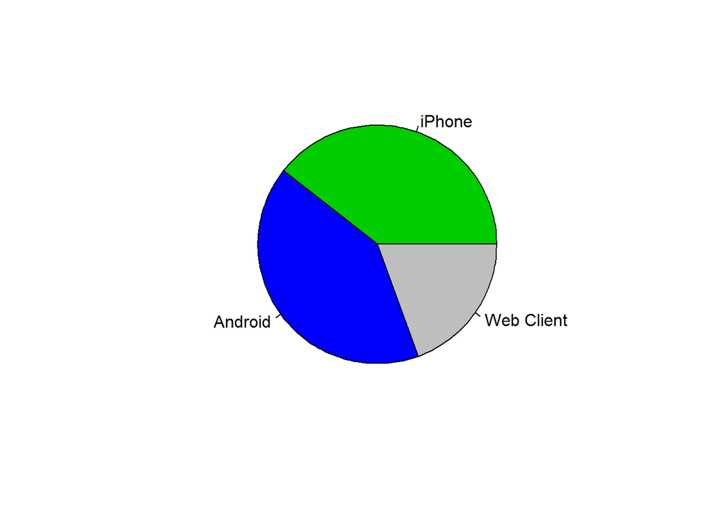

Możemy postawić hipotezę, że zdecydowanie najpopularniejszymi urządzeniami do tweet’owania są iPhone’y oraz telefony z systemem Android. Dostępność w dowolnym momencie i szybkość przekazu to zdecydowanie najważniejsze czynniki obecnie.

## 4. Ale cóż to były za emocje..

Wszystkie konkursy wywołują w nas wiele emocji. Każdy z nas chce wygrywać lub przynajmniej, aby jego kandydat/faworyt został zwycięzcą. Niektórzy nie wytrzymując tak silnej dawki emocji, zaczynają korzystać z pewnego środka odstresowującego zwanego potocznie inwektywami - tj. rzucamy mięsem. Zbadajmy jak dużo tweet’ów z naszej próbki skorzystało z tego środka odstresowującego.

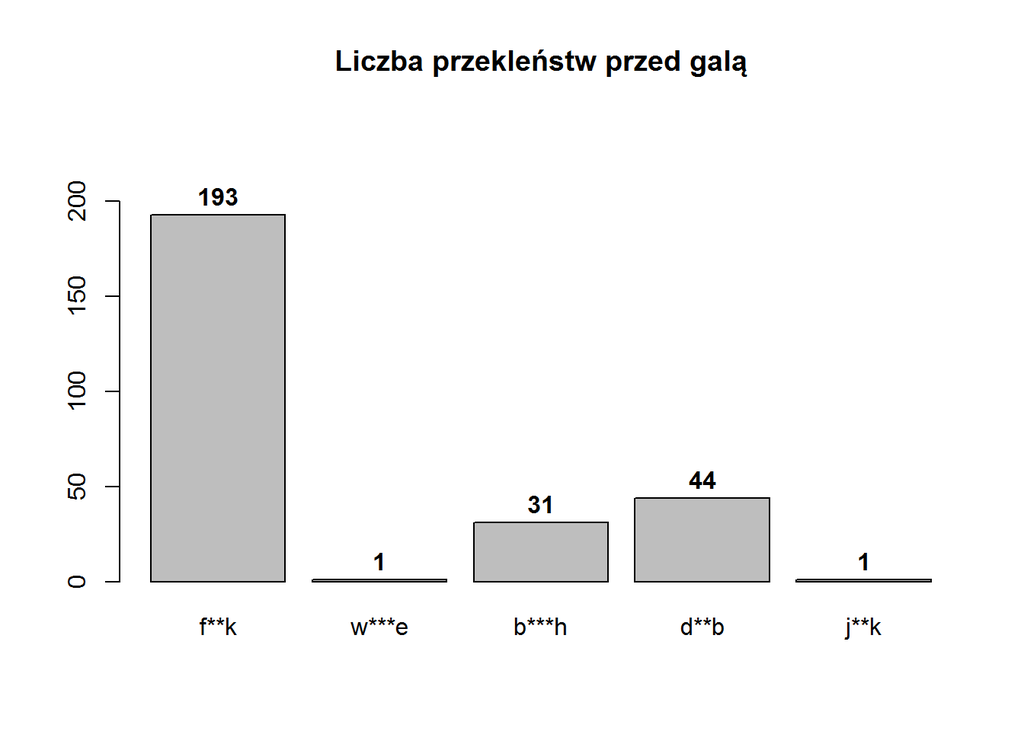

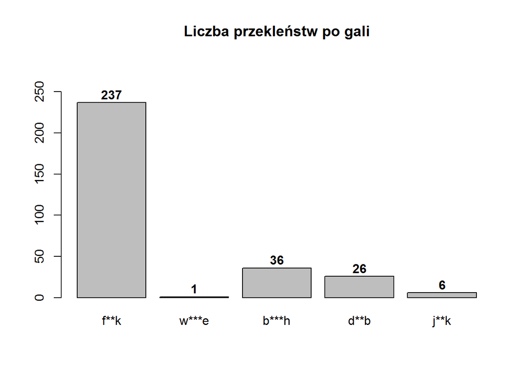

Jak widzimy liczba przekleństw cechuje się pewną stałością w czasie. Jedynie w przypadku słowa _f**k_ mogliśmy zaobserwować wzrost o ponad 40 wystąpień po gali.

# Podsumowanie

Jak widzimy korzystając z historii Tweeter’a możemy pobierać i przetwarzać dane na wiele sposobów. Niestety największym mankamentem poboru danych z historii jest to, iż tracimy np. dane o lokalizacji - porównując do obserwowania w czasie rzeczywistym podczas którego te dane możemy wyłuskąć. Jednakże, wciąż pozostaje nam najistotniejsza do analiz część tweet’a - mianowicie jego treść!